# Schmidt_Emily_TP0

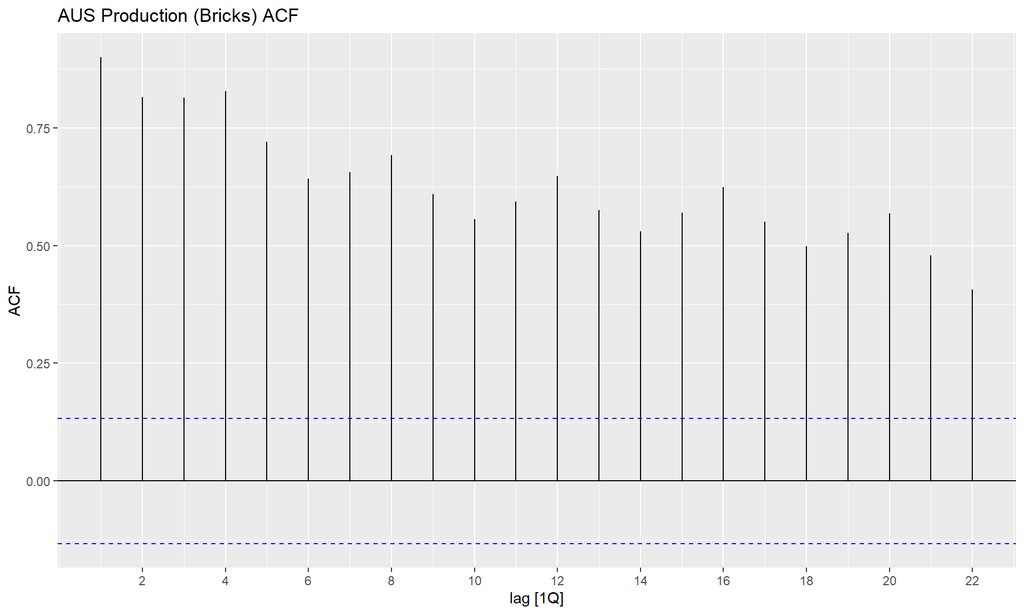

*Description*: Hudson Bay Company trading records for Snowshoe Hare and Canadian Lynx furs from 1845 to 1935. This data contains trade records for all areas of the company.

```
## # A tsibble: 91 x 3 [1Y]
##     Year  Hare  Lynx
##    <dbl> <dbl> <dbl>
##  1  1845 19580 30090
##  2  1846 19600 45150
##  3  1847 19610 49150
##  4  1848 11990 39520
##  5  1849 28040 21230
##  6  1850 58000  8420
##  7  1851 74600  5560
##  8  1852 75090  5080
##  9  1853 88480 10170
## 10  1854 61280 19600
## # ℹ 81 more rows
```

```
## <interval[1]>
## [1] 1Y
```

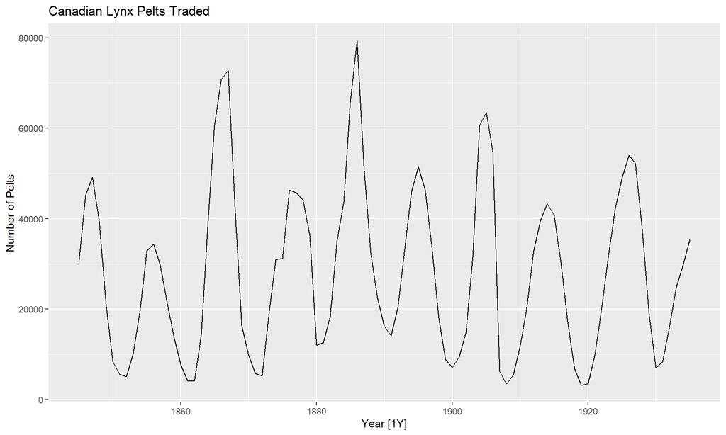

**(c)** From 1845 to 1935, the Hudson Bay Company publicized their trading records for two types of furs, Hare and Lynx. The Canadian Lynx pelts trend is shown above. Since there are consistent mountains and valleys throughout the data, nothing appears to be completely unusual. The one observation worth mentioning though is where there are a relatively flat number of trading records around 1875. This does not appear in any of the other positive trending peaks. Additional details will be discussed in question **2.**

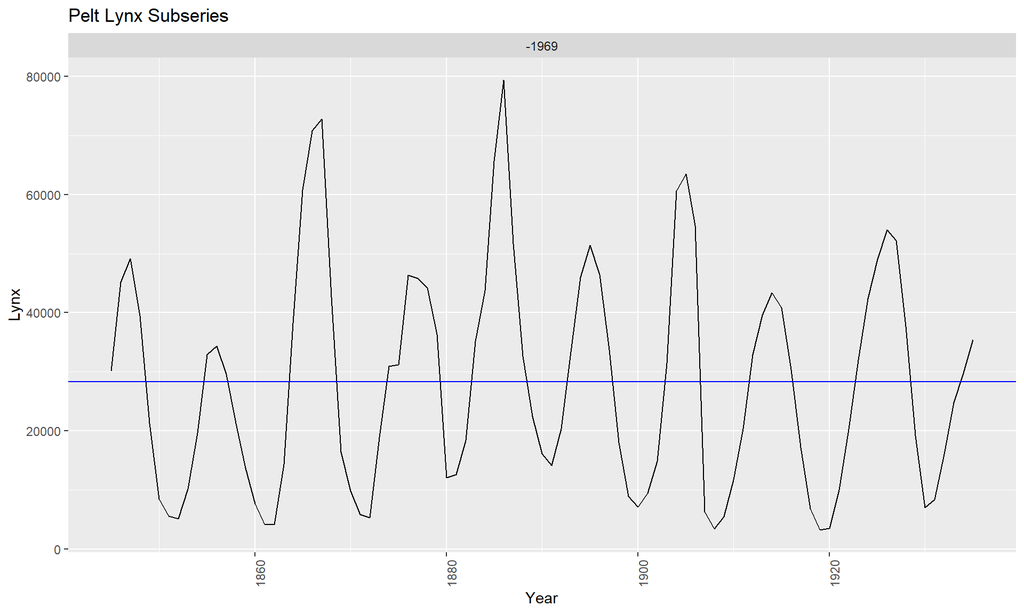

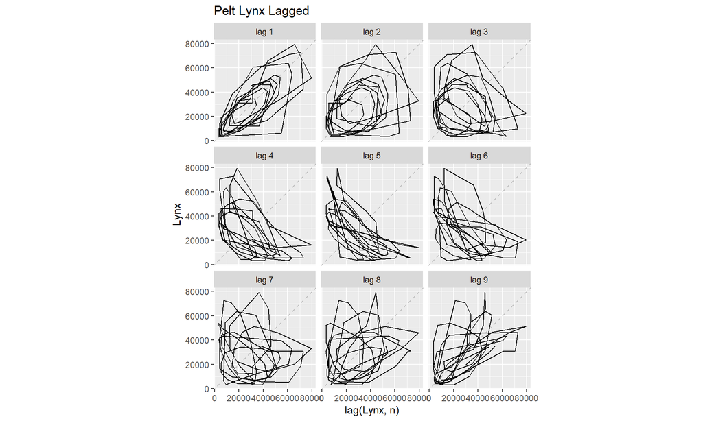

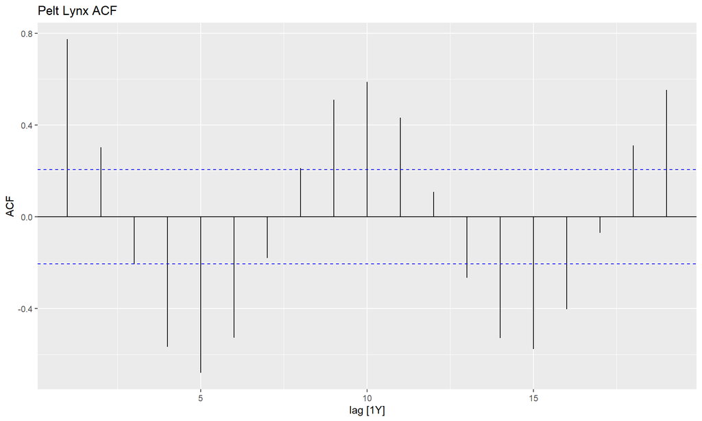

*Description*: Historical stock prices from 2014-2018 for Google, Amazon, Facebook and Apple. All prices are in $USD.

```
## # A tsibble: 5,032 x 8 [!]
## # Key:       Symbol [4]
##    Symbol Date        Open  High   Low Close Adj_Close    Volume
##    <chr>  <date>     <dbl> <dbl> <dbl> <dbl>     <dbl>     <dbl>
##  1 AAPL   2014-01-02  79.4  79.6  78.9  79.0      67.0  58671200
##  2 AAPL   2014-01-03  79.0  79.1  77.2  77.3      65.5  98116900
##  3 AAPL   2014-01-06  76.8  78.1  76.2  77.7      65.9 103152700
##  4 AAPL   2014-01-07  77.8  78.0  76.8  77.1      65.4  79302300
##  5 AAPL   2014-01-08  77.0  77.9  77.0  77.6      65.8  64632400
##  6 AAPL   2014-01-09  78.1  78.1  76.5  76.6      65.0  69787200
##  7 AAPL   2014-01-10  77.1  77.3  75.9  76.1      64.5  76244000
##  8 AAPL   2014-01-13  75.7  77.5  75.7  76.5      64.9  94623200
##  9 AAPL   2014-01-14  76.9  78.1  76.8  78.1      66.1  83140400
## 10 AAPL   2014-01-15  79.1  80.0  78.8  79.6      67.5  97909700
## # ℹ 5,022 more rows
```

```
## <interval[1]>
## [1] !
```

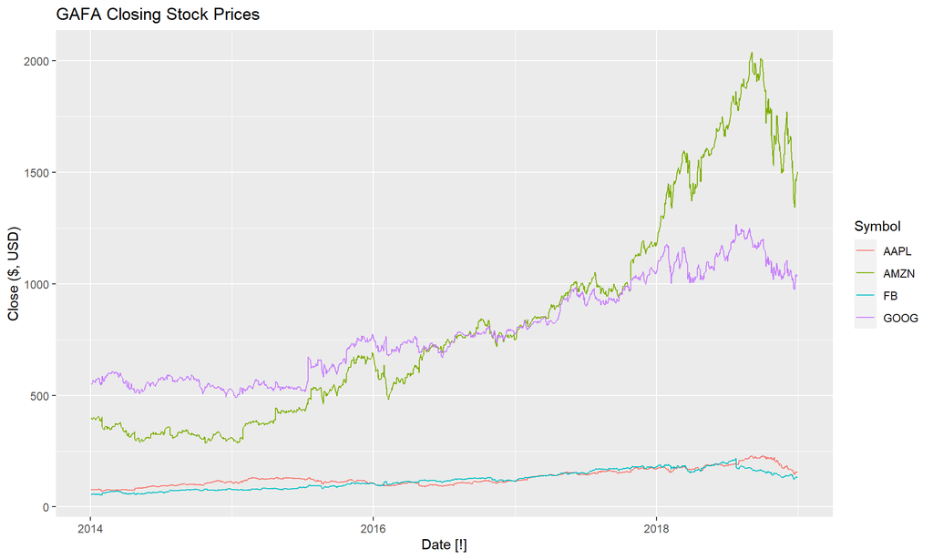

**(c)** GAFA stands for Google, Apple, Facebook, and Amazon. The data provided above are historical closing stock prices for each corporation from 2014 to 2018. Other than the Amazon’s larger closing price increase from 4Q 2017 to 3Q 2018 (when it surpassed `GOOG`), there are no unusual observations at this time that are worth mentioning. In order to analyze if there are irregular data points, the graph’s scale may need to be reduced to monthly intervals and an individual review of each company will need to be conducted to analyze possible changes in closing price around any of the peaks and/or dips.

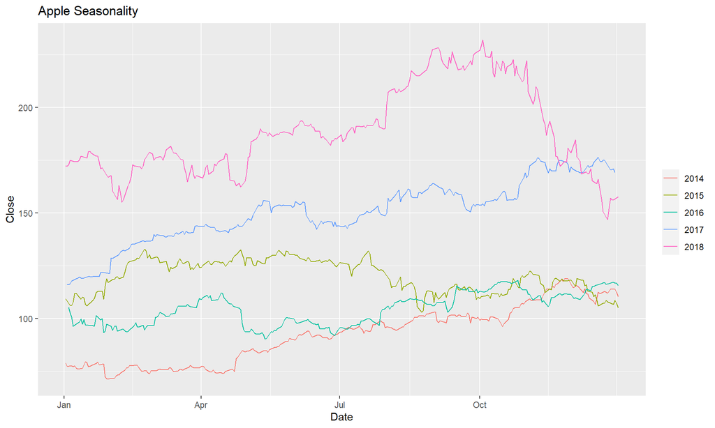

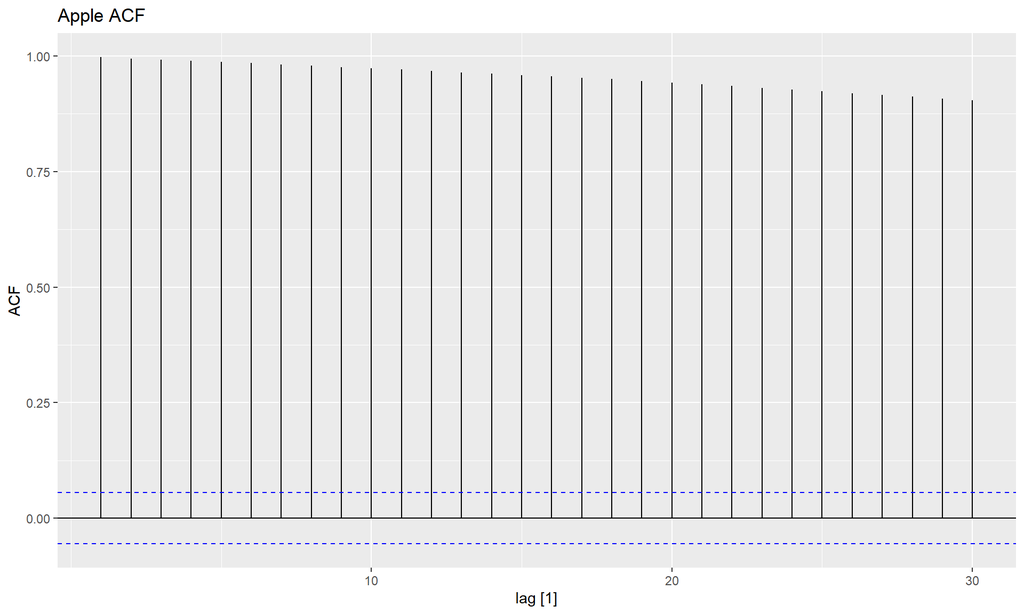

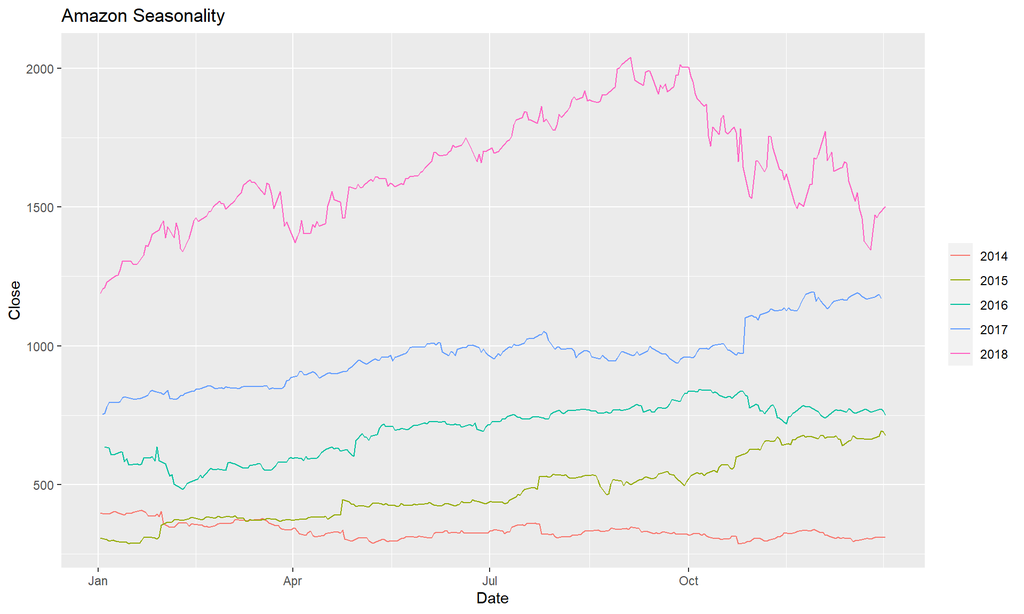

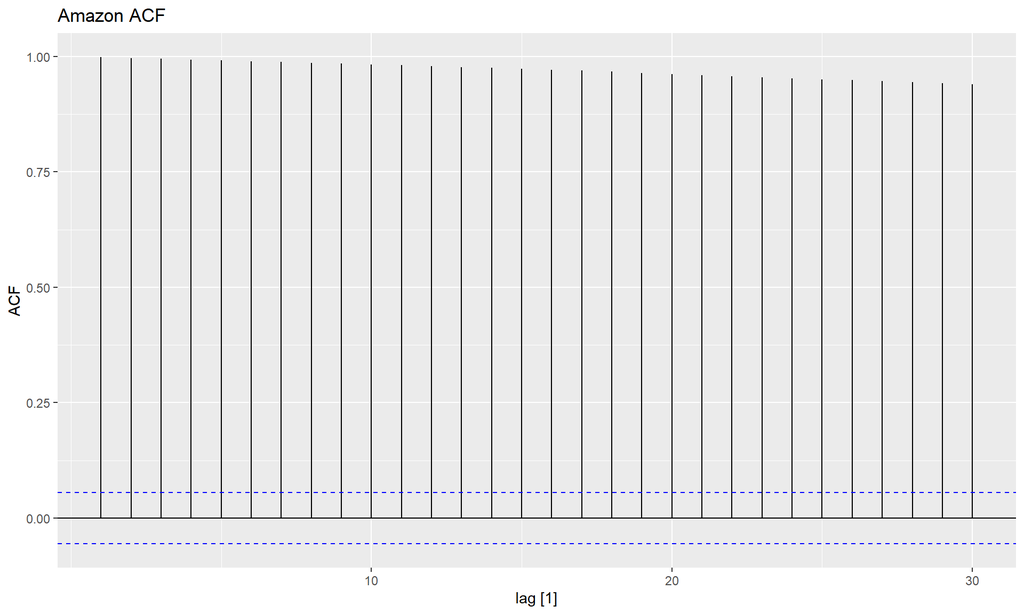

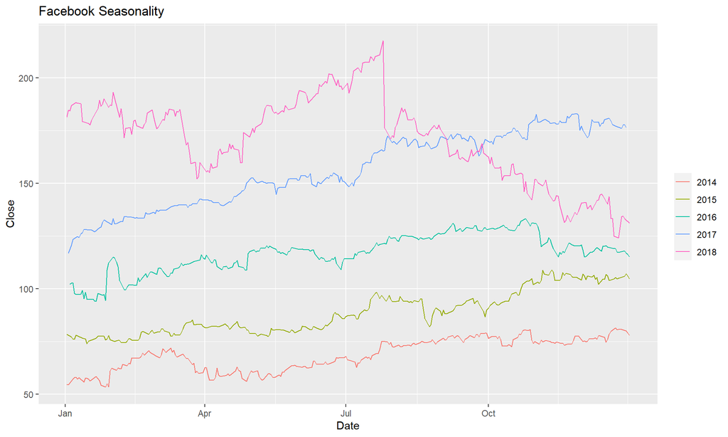

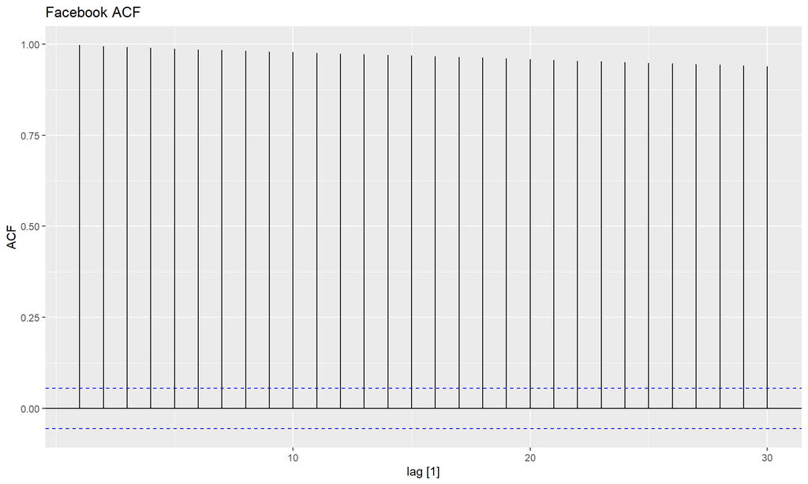

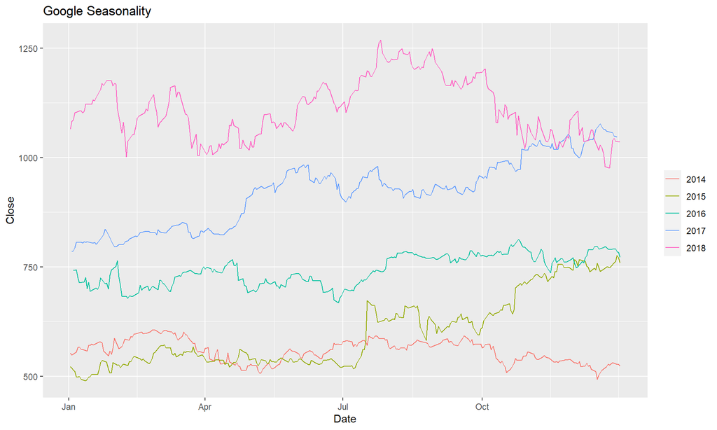

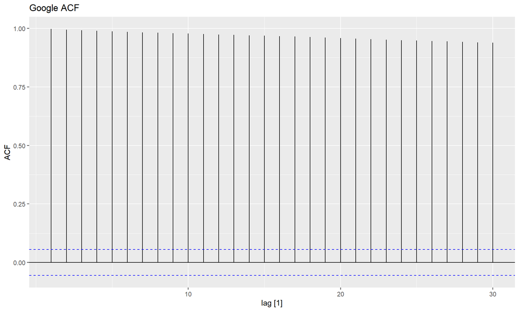

*Description*: `vic_elec` is a half-hourly tsibble with three values:  
• Demand: Total electricity demand in MWh.  
• Temperature: Temperature of Melbourne (BOM site 086071).  
• Holiday: Indicator for if that day is a public holiday.

```
## # A tsibble: 52,608 x 5 [30m] <Australia/Melbourne>
##    Time                Demand Temperature Date       Holiday
##    <dttm>               <dbl>       <dbl> <date>     <lgl>
##  1 2012-01-01 00:00:00  4383.        21.4 2012-01-01 TRUE
##  2 2012-01-01 00:30:00  4263.        21.0 2012-01-01 TRUE
##  3 2012-01-01 01:00:00  4049.        20.7 2012-01-01 TRUE
##  4 2012-01-01 01:30:00  3878.        20.6 2012-01-01 TRUE
##  5 2012-01-01 02:00:00  4036.        20.4 2012-01-01 TRUE
##  6 2012-01-01 02:30:00  3866.        20.2 2012-01-01 TRUE
##  7 2012-01-01 03:00:00  3694.        20.1 2012-01-01 TRUE
##  8 2012-01-01 03:30:00  3562.        19.6 2012-01-01 TRUE
##  9 2012-01-01 04:00:00  3433.        19.1 2012-01-01 TRUE
## 10 2012-01-01 04:30:00  3359.        19.0 2012-01-01 TRUE
## # ℹ 52,598 more rows
```

```
## <interval[1]>
## [1] 30m
```

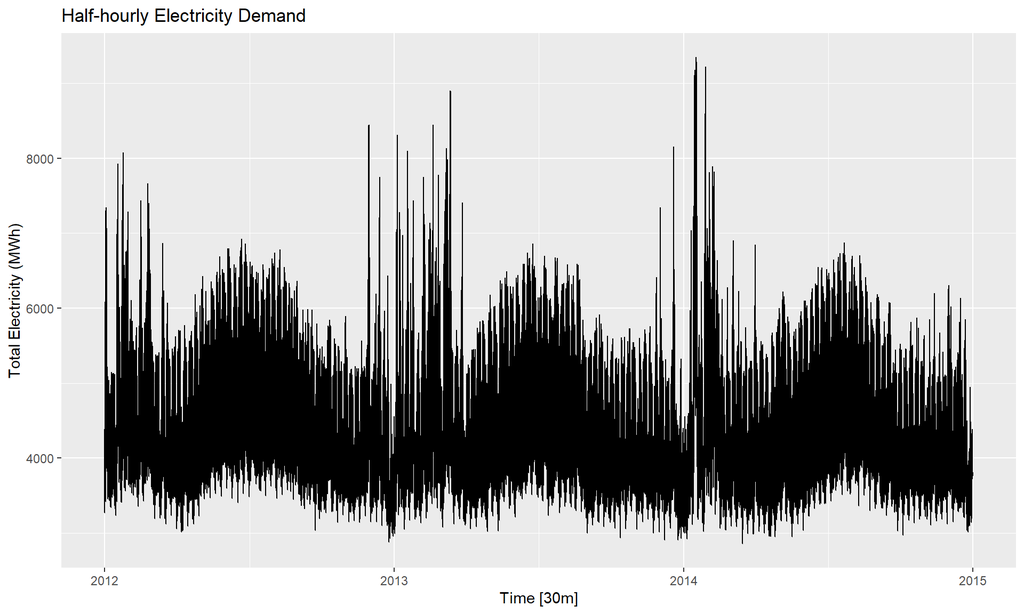

**(c)** The last data set provides information on Victoria’s half-hourly electricity demand in Australia. From 2012 through 2014, there is a decent amount of fluctuation from the beginning of the years into what appears to be close to the end of 1Q. Since there is a pattern throughout each year, it is hard to tell if there are any unique observations since seasonality appears to be driving those high peaks and constant directional changes. If there were an unusual data point, the data would need to be more granular (per year, weekly, etc.)

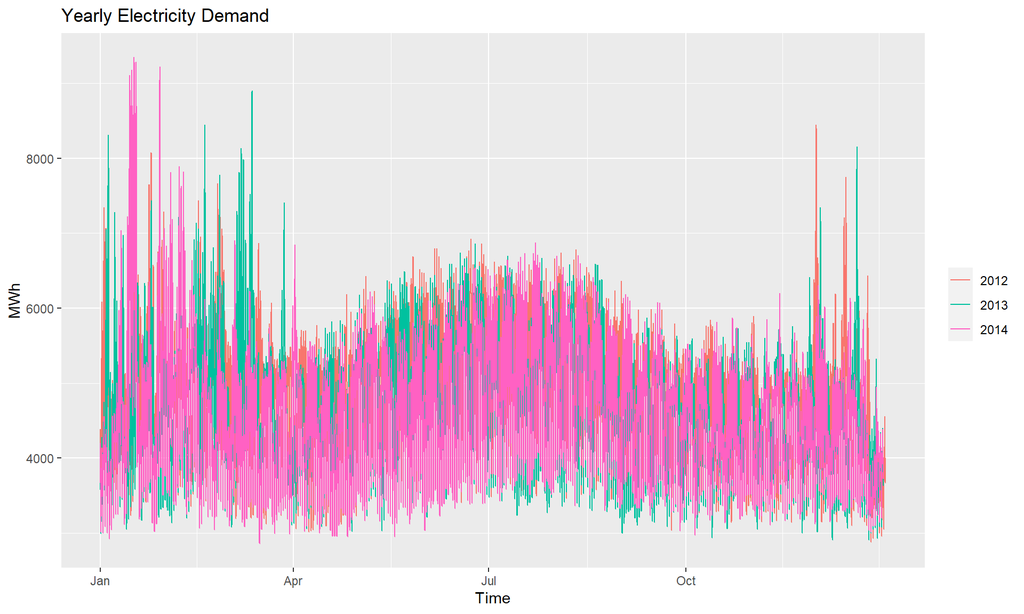

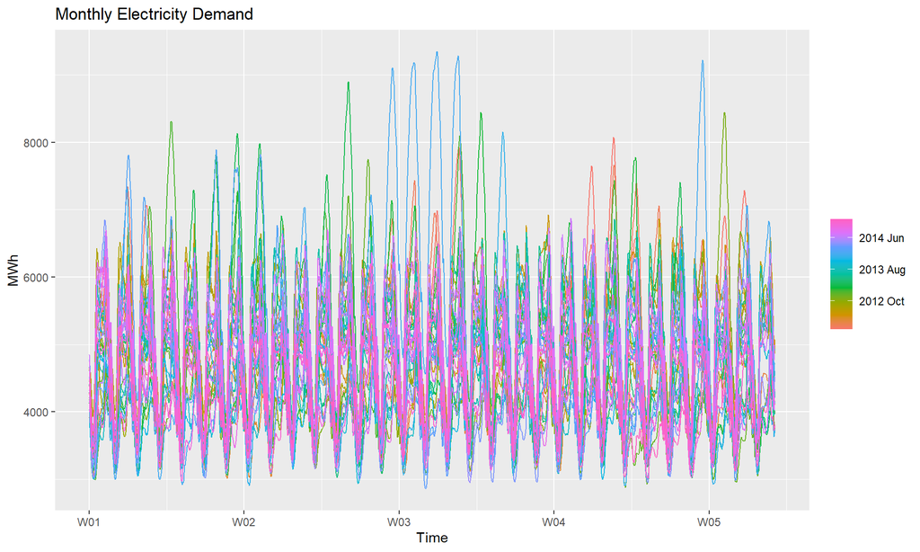

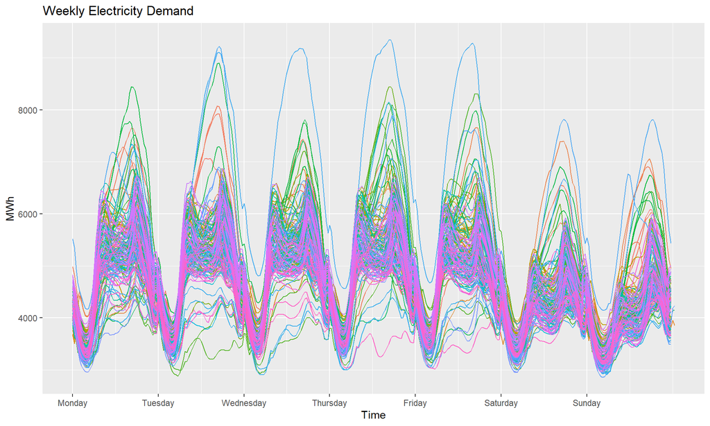